# NTRES 6600 - Lesson 3

Nina Overgaard Therkildsen

2/5/2020

# Importing, Reformatting and Tidying Data in R

This lesson was adapted from the course [R for Excel Users](https://github.com/rstudio-conf-2020/r-for-excel) by Julia Stewart Lowndes and Allison Horst

#### Objectives

In this session we’ll learn some tools to import data into R and help make data **tidy** and more coder-friendly. Those include:

- Practice data import to R
- Reshape dataframes with `tidyr::pivot_wider()` and `tidyr::pivot_longer()`
- Make column headers more manageable with `janitor::clean_names()`
- Merge or separate information from different columns`tidyr::unite()` and `tidyr::separate()`
- Detect or replace a string with `stringr` functions
- Conditionally subset our data by rows with `dplyr::filter()`, and
- Merge data frames together `dplyr::*_join()` functions

#### Resources

- [Ch. 12 *Tidy Data*, in R for Data Science](https://r4ds.had.co.nz/tidy-data.html) by Grolemund & Wickham
- [Jenny Bryan’s Intro to Tidy Data](https://github.com/jennybc/lotr-tidy/blob/master/01-intro.md)
  - the repo this links to has some useful exercises too, but uses the older `spread()` and `gather()` functions.
- `tidyr` [vignette on tidy data](https://cran.r-project.org/web/packages/tidyr/vignettes/tidy-data.html).
- [Hadley’s paper on tidy data](https://vita.had.co.nz/papers/tidy-data.pdf) provides a thorough investigation.

#### Prerequisites

Before the class, please make sure you have done the following:

1. **Download and install R and RStudio**
   - R: https://cloud.r-project.org/
   - RStudio: http://www.rstudio.com/download
   - Follow your operating system’s normal installation process
2. **Download workshop data ([details about the data sources here](https://github.com/rstudio-conf-2020/r-for-excel/blob/master/index.Rmd))**
   - Google Drive folder: [r-for-excel-data](https://drive.google.com/drive/folders/1RywSUw8hxETlROdIhLIntxPsZq0tKSdS?usp=sharing)
   - Save it temporarily somewhere you will remember; we will move it together

## PART 1: Set-up

### RStudio Orientation

What is the RStudio IDE (integrated development environment)? The RStudio IDE is software that greatly improves your R experience.

I think that **R is your airplane, and the RStudio IDE is your airport**. You are the pilot, and you use R to go places! With practice you’ll gain skills and confidence; you can fly further distances and get through tricky situations. You will become an awesome pilot and can fly your plane anywhere. And the RStudio IDE provides support! Runways, communication, community, and other services that makes your life as a pilot much easier. It provides not only the infrastructure but a hub for the community that you can interact with.

To launch RStudio, double-click on the RStudio icon. Launching RStudio also launches R, and you will probably never open R by itself.

[figure not shown]

Notice the default panes:

- Console (entire left)
- Environment/History (tabbed in upper right)
- Files/Plots/Packages/Help (tabbed in lower right)

We won’t click through this all immediately but we will become familiar with more of the options and capabilities throughout the next few days.

Something critical to know now is that you can make everything you see BIGGER by going to the navigation pane: View > Zoom In. Learn these keyboard shortcuts; being able to see what you’re typing will help avoid typos & help us help you.

An important first question: **where are we?**

If you’ve have opened RStudio for the first time, you’ll be in your Home directory. This is noted by the `~/` at the top of the console. You can see too that the Files pane in the lower right shows what is in the Home directory where you are. You can navigate around within that Files pane and explore, but note that you won’t change where you are: even as you click through you’ll still be Home: `~/`.

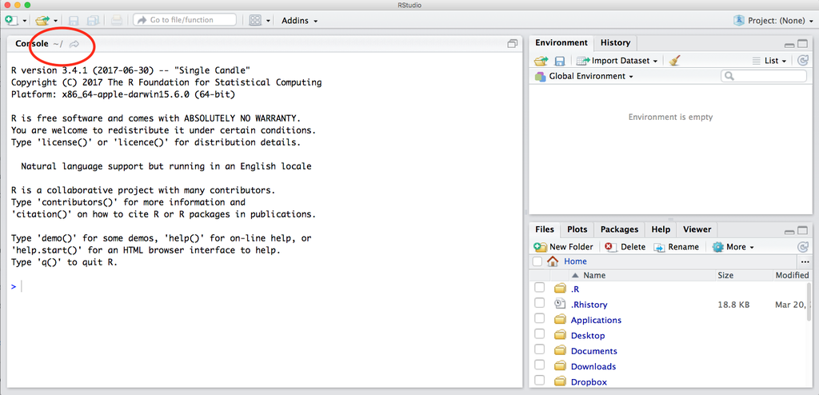

### Using R

If you’re not familiar with R and RStudio, there are lots of excellent tutorials online, including

- [Chapter 3 from the R for Excel course by Lowndes and Horst](https://rstudio-conf-2020.github.io/r-for-excel/rstudio.html)
- [Data Carpentry’s Introduction to R lesson](https://datacarpentry.org/R-ecology-lesson/)

### Installing and attaching packages

First we need to make sure that we have all the packages we will need for today’s tutorial - `tidyverse` - `here` - `janitor` - `readxl`

Run the following lines of code in RStudio if you don’t already have these packages installed

```r
# Install packages
install.packages("tidyverse")
install.packages("janitor")
install.packages("readxl")
```

Now to make each package accessible in our session, we’ll have a attach them with the following code (`library(package_name)`):

```r
# Attach packages
library(tidyverse)
library(janitor)
library(readxl)
```

### Starting a project in RStudio

```r
getwd()
```

```
#> [1] "/Users/hadley/Documents/r4ds/r4ds"
```

It is beyond the scope of this tutorial to cover how relative and absolute paths work in R, but there is a great description [in Chapter 7 of Grolemund and Wickham’s book R for Data Science](https://r4ds.had.co.nz/workflow-projects.html). The rest of this section is adapted from this chapter.

In this tutorial, we will create an RStudio project to make sure we keep everything in one place.

Click File > New Project, then:

[figure not shown]

[figure not shown]

[figure not shown]

Call your project `r4ds` and think carefully about which *subdirectory* you put the project in. If you don’t store it somewhere sensible, it will be hard to find it in the future!

Once this process is complete, you’ll get a new RStudio project just for this tutorial. Check that the “home” directory of your project is the current working directory:

```r
getwd()
```

```
#> [1] /Users/hadley/Documents/r4ds/r4ds
```

Whenever you refer to a file with a relative path it will look for it here. Now in your favorite OS-specific way, unzip the folder you downloaded with data files and copy it into the project folder so that we can easily find it.

## PART 2: Importing data into R

In this section, we’ll learn how to read some external data (from .xls, .xlsx, and CSV files) into R with the `readr` and `readxl` packages (both part of the `tidyverse`).

### Resources

- https://readr.tidyverse.org/ from tidyverse.org
- https://readxl.tidyverse.org/ from tidyverse.org
- https://readxl.tidyverse.org/articles/articles/readxl-workflows.html from tidyverse.org

## Read in .xlsx and .csv files

We’ll start by reading in data for parks visitation from two files:

- A comma-separated-value (CSV) file containing visitation data for all National Parks in California (ca_np.csv)
- A single Excel worksheet containing only visitation for Channel Islands National Park (ci_np.xlsx)

### `read_csv()` to read in comma-separated-value (.csv) files

There are many types of files containing data that you might want to work with in R. A common one is a comma separated value (CSV) file, which contains values with each column entry separated by a comma delimiter. CSVs can be opened, viewed, and worked with in Excel just like an .xls or .xlsx file - but let’s learn how to get data directly from a CSV into R where we can work with it more reproducibly.

To read in the ca_np.csv file, we need to:

- use `read_csv()` to read in the file
- assign the stored data an object name (we’ll store ours as ca_np)

```r
ca_np <- read_csv("data/ca_np.csv")
```

Look in your Environment to see that **ca_np** now shows up. Click on the object in the Environment, and R will automatically run the `View()` function for you to pull up your data in a separate viewing tab. Now we can look at it in the spreadsheet format we’re used to.

We can explore our data frame a bit more to see what it contains. For example:

- `names()`: to see the variable (column) names
- `head()`: to see the first *x* rows (6 is the default)
- `summary()`: see a quick summary of each variable

Cool! We can also read in a file directly from the web/cloud by using the URL in place of the file path.

```r
ca_np  <- read_csv("https://raw.githubusercontent.com/nt246/tidy-data-in-r/master/data/ca_np.csv")
```

### `readxl` to read in Excel files

We also have an Excel file (ci_np.xlsx) that contains observations **only** for Channel Islands National Park visitation. Both `readr` and `readxl` are part of the `tidyverse`, which means we should expect their functions to have similar syntax and structure.

*Note: If `readxl` is part of the `tidyverse`, then why did I have to attach it separately?* Great question! Too keep the `tidyverse` manageable, there are “core” packages (`readr`, `dplyr`, `tidyr`, `ggplot2`, `forcats`, `purrr`, `tibble`, `stringr`) that you would expect to use frequently, and those are automatically attached when you use `library(tidyverse)`. But there are *also* more specialized `tidyverse` packages (e.g. `readxl`, `reprex`, `lubridate`, `rvest`) that are built with similar design philosophy, but are not automatically attached with `library(tidyverse)`. Those specialized packages are **installed** along with the `tidyverse`, but need to be attached individually (e.g. with `library(readxl)`).

```r
ci_np <- read_excel("data/ci_np_2sheets.xlsx")
```

If we’re dealing with an Excel file with multiple tabs, the default behavior `read_excel()` is to import the first tab, but we can also specify which tab we want imported:

```r
ci_np <- read_excel("data/ci_np_2sheets.xlsx", "Sheet1")
```

### Other data import functions

There are many other functions for reading data into R

- `read_csv()` reads comma delimited files, `read_csv2()` reads semicolon separated files (common in countries where `,` is used as the decimal place), `read_tsv()` reads tab delimited files, and `read_delim()` reads in files with any delimiter.
- `read_fwf()` reads fixed width files. You can specify fields either by their widths with `fwf_widths()` or their position with `fwf_positions()`. `read_table()` reads a common variation of fixed width files where columns are separated by white space.
- `googlesheets::gs_read()` from the package [googlesheets](https://cran.r-project.org/web/packages/googlesheets/vignettes/basic-usage.html#read-all-the-data-in-one-worksheet) reads in data directly from Google Sheets

## PART 3: Tidy data - Recap from last lesson and tools for reformatting

> If I had one thing to tell biologists learning bioinformatics, it would be “write code for humans, write data for computers”.

> — Vince Buffalo (@vsbuffalo) [July 20, 2013](https://twitter.com/vsbuffalo/statuses/358699162679787521)

Now that we know how to import data in RStudio, we want to make sure it’s “tidy”. “Tidy” might sound like a generic way to describe non-messy looking data, but it is actually a specific data structure.

When data is *tidy*, it is rectangular with each variable as a column, each row an observation, and each cell contains a single value (see: [Ch. 12 in R for Data Science by Grolemund & Wickham](https://r4ds.had.co.nz/tidy-data.html)).

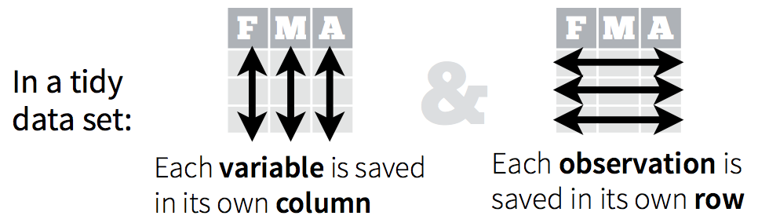

### Read in example data

We’ve used both `read_csv()` and `read_excel()` to import data from spreadsheets into R.

Use `read_excel()` to read in the **inverts.xlsx** data as an objected called **inverts**.

```r
inverts <- read_excel("data/inverts.xlsx")
```

Be sure to explore the imported data a bit:

```r
View(inverts)
names(inverts)
summary(inverts)
```

## `tidyr::pivot_longer()` to reshape from wider-to-longer format

If we look at *inverts*, we can see that the *year* variable is actually split over 3 columns, so we’d say this is currently in **wide format**.

There may be times when you want to have data in wide format, but often with code it is more efficient to convert to **long format** by gathering together observations for a variable that is currently split into multiple columns.

Schematically, converting from wide to long format using `pivot_longer()` looks like this:

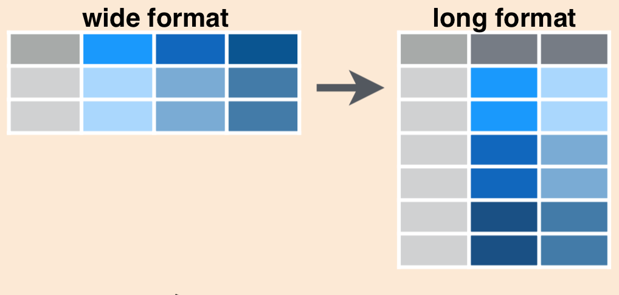

`pivot_longer()` takes a data frame, and returns a data frame. The arguments after the data argument that we’ll need are:

- `cols` for the column names that we want to turn into a single column.
- `names_to`: the old column names are going to a new column. What should this new column be named? (optional, but highly recommended)
- `values_to`: the values underneath the old columns are going to a new column. What should this new column be named? (optional, but highly recommended)

We’ll use `tidyr::pivot_longer()` to gather data from all years in *inverts* (columns `2016`, `2017`, and `2018`) into two columns:

- one called *year*, which contains the year
- one called *sp_count* containing the number of each species observed.

The new data frame will be stored as *inverts_long*:

```r
# Note: Either single-quotes, double-quotes, OR backticks around years work!
inverts_long <- pivot_longer(data = inverts,
                                    cols = '2016':'2018',
                                    names_to = "year",
                                    values_to = "sp_count")
```

The outcome is the new long-format *inverts_long* data frame:

```r
inverts_long
```

```
## # A tibble: 165 x 5
##    month site  common_name              year  sp_count
##    <chr> <chr> <chr>                    <chr>    <dbl>
##  1 7     abur  california cone snail    2016       451
##  2 7     abur  california cone snail    2017        28
##  3 7     abur  california cone snail    2018       762
##  4 7     abur  california spiny lobster 2016        17
##  5 7     abur  california spiny lobster 2017        17
##  6 7     abur  california spiny lobster 2018        16
##  7 7     abur  orange cup coral         2016        24
##  8 7     abur  orange cup coral         2017        24
##  9 7     abur  orange cup coral         2018        24
## 10 7     abur  purple urchin            2016        48
## # … with 155 more rows
```

Hooray, long format!

## `tidyr::pivot_wider()` to convert from longer-to-wider format

In the previous example, we had information spread over multiple columns that we wanted to *gather*. Sometimes, we’ll have data that we want to *spread* over multiple columns.

For example, imagine that starting from *inverts_long* we want each species in the *common_name* column to exist as its **own column**. In that case, we would be converting from a longer to a wider format, and will use `tidyr::pivot_wider()`.

Like `pivot_longer()`, `pivot_wider()` takes a data frame and returns a data frame. The arguments after the data argument that we’ll need are:

- `names_from`: the new column names are coming from an old column. Which column is this?
- `values_from`: the values under the new columns are coming from an old column. Which column is this?

Specifically for our data, we’ll use `pivot_wider()` to spread the *common_name* across multiple columns as follows:

```r
inverts_wide <- inverts_long %>%
  pivot_wider(names_from = common_name,
                     values_from = sp_count)
```

```r
inverts_wide
```

```
## # A tibble: 33 x 8
##    month site  year  `california con… `california spi… `orange cup cor…
##    <chr> <chr> <chr>            <dbl>            <dbl>            <dbl>
##  1 7     abur  2016               451               17               24
##  2 7     abur  2017                28               17               24
##  3 7     abur  2018               762               16               24
##  4 7     ahnd  2016                27               16               24
##  5 7     ahnd  2017                24               16               24
##  6 7     ahnd  2018                24               16               24
##  7 7     aque  2016              4971               48             1526
##  8 7     aque  2017              1752               48             1623
##  9 7     aque  2018              2616               48             1859
## 10 7     bull  2016              1735               24               36
## # … with 23 more rows, and 2 more variables: `purple urchin` <dbl>, `rock
## #   scallop` <dbl>
```

We can see that now each *species* has its own column (wider format).

### Your turn - Exercise

Now, let’s try these functions to tidy up and reorganize a completely different dataset.

Take a look at the [three data tables](https://github.com/jennybc/lotr-tidy/blob/master/01-intro.md) that Jenny Bryan has compiled based on data from the Lord of the Rings trilogy.

Look at the tables above and answer these questions:

- What’s the total number of words spoken by male hobbits?
- Does a certain `Race` dominate a movie? Does the dominant `Race` differ across the movies?

How well does your approach scale if there were many more movies or if I provided you with updated data that includes all the `Races` (e.g. dwarves, orcs, etc.)?

#### Tasks

1. Let’s read the data into RStudio. A .csv file with the three tables stacked together into one table is available here: https://raw.githubusercontent.com/nt246/tidy-data-in-r/master/data/lotr_table.csv. You can either download the file and put it in your data folder, or you can read it in directly with the URL.
2. Are these data in tidy format? If not, use the `pivot_longer()` function to make the data tidy.
3. After tidying the data and completing your analysis, you may want to output a table that has each race in its own column. Use the `pivot_wider()` function to make such a table and save it as `lotr_wide`.
4. OPTIONAL: Use the `pivot_longer()` function to transform you `lotr_wide` back to tidy format.

## PART 4. Cleaning up column names with `janitor::clean_names()`

If we go back to our `inverts_wide`, we see that each *species* has its own column. But also notice that those column headers (since they have spaces) might not be in the most coder-friendly format…

The `janitor` package by Sam Firke is a great collection of functions for some quick data cleaning, like:

- `janitor::clean_names()`: update column headers to a case of your choosing
- `janitor::get_dupes()`: see all rows that are duplicates within variables you choose
- `janitor::remove_empty()`: remove empty rows and/or columns
- `janitor::adorn_*()`: jazz up tables

Here, we’ll use `janitor::clean_names()` to convert all of our column headers to a more convenient case - the default is **lower_snake_case**, which means all spaces and symbols are replaced with an underscore (or a word describing the symbol), all characters are lowercase, and a few other nice adjustments.

For example, `janitor::clean_names()` would update these nightmare column names into much nicer forms:

- `My...RECENT-income!` becomes `my_recent_income`
- `SAMPLE2.!test1` becomes `sample2_test1`
- `ThisIsTheName` becomes `this_is_the_name`
- `2015` becomes `x2015`

If we wanted to then use these columns (which we probably would, since we created them), we could clean the names to get them into more coder-friendly lower_snake_case with `janitor::clean_names()`:

```r
inverts_wide <- inverts_wide %>%
  clean_names()
```

```r
names(inverts_wide)
```

```
## [1] "month"                    "site"
## [3] "year"                     "california_cone_snail"
## [5] "california_spiny_lobster" "orange_cup_coral"
## [7] "purple_urchin"            "rock_scallop"
```

And there are other case options in `clean_names()`, like:

- “snake” produces snake_case (the default)
- “lower_camel” or “small_camel” produces lowerCamel
- “upper_camel” or “big_camel” produces UpperCamel
- “screaming_snake” or “all_caps” produces ALL_CAPS
- “lower_upper” produces lowerUPPER
- “upper_lower” produces UPPERlower

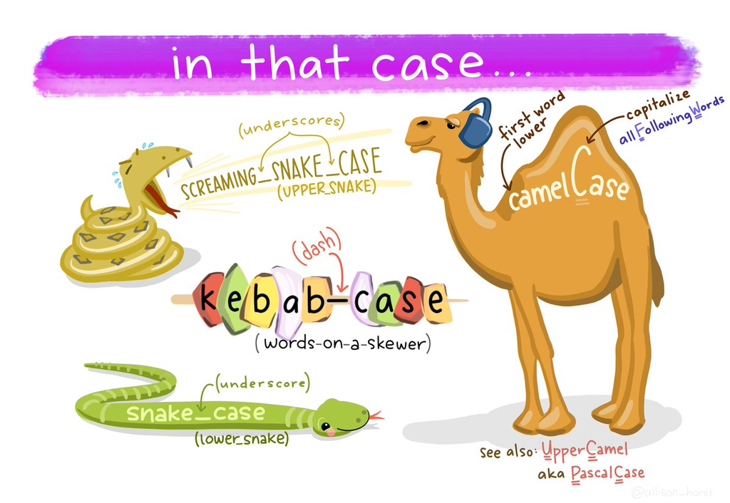

## PART 5: Combine or separate information in column(s) with`tidyr::unite()` and `tidyr::separate()`

Sometimes we’ll want to *separate* contents of a single column into multiple columns, or *combine* entries from different columns into a single column.

For example, the following data frame has *genus* and *species* in separate columns:

| id | genus | species | common_name |
| --- | --- | --- | --- |
| 1 | Scorpaena | guttata | sculpin |
| 2 | Sebastes | miniatus | vermillion |
| 3 | Gadus | macrocephalus | Pacific cod |

Or we may want to do the reverse (separate information from a single column into multiple columns). Here, we’ll learn `tidyr::unite()` and `tidyr::separate()` to help us do both.

### `tidyr::unite()` to merge information from separate columns

Use `tidyr::unite()` to combine information from multiple columns into a single column (as for the scientific name example above)

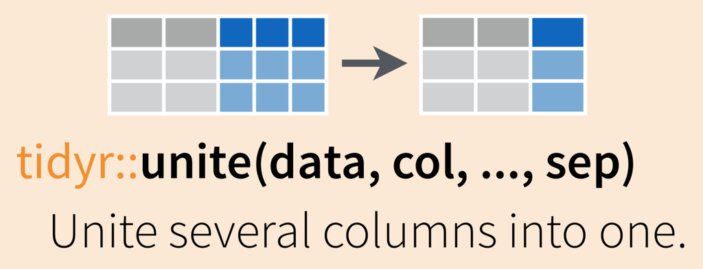

To demonstrate uniting information from separate columns, we’ll make a single column that has the combined information from *site* abbreviation and *year* in *inverts_long*.

We need to give `tidyr::unite()` several arguments:

- **data:** the data frame containing columns we want to combine (or pipe into the function from the data frame)
- **col:** the name of the new “united” column
- the **columns you are uniting**
- **sep:** the symbol, value or character to put between the united information from each column

```r
inverts_unite <- inverts_long %>%
  unite(col = "site_year", # What to name the new united column
               c(site, year), # The columns we'll unite (site, year)
               sep = "_") # How to separate the things we're uniting
```

[output not shown]

### Your turn:

**Task:** Create a new object called ‘inverts_moyr’, starting from inverts_long, that unites the month and year columns into a single column named “mo_yr”, using a slash “/” as the separator. Then try updating the separator to something else! Like “*hello!*”.

**Solution:**

```r
inverts_moyr <- inverts_long %>%
  unite(col = "mo_yr", # What to name the new united column
               c(month, year), # The columns we'll unite (site, year)
               sep = "/")
```

**Merging information from > 2 columns (not done in workshop)**

`tidyr::unite()` can also combine information from *more* than two columns. For example, to combine the *site*, *common_name* and *year* columns from *inverts_long*, we could use:

```r
# Uniting more than 2 columns:
inverts_triple_unite <- inverts_long %>%
  unite(col = "year_site_name",
               c(year, site, common_name),
               sep = "-") # Note: this is a dash
```

```r
head(inverts_triple_unite)
```

```
## # A tibble: 6 x 3
##   month year_site_name                     sp_count
##   <chr> <chr>                                 <dbl>
## 1 7     2016-abur-california cone snail         451
## 2 7     2017-abur-california cone snail          28
## 3 7     2018-abur-california cone snail         762
## 4 7     2016-abur-california spiny lobster       17
## 5 7     2017-abur-california spiny lobster       17
## 6 7     2018-abur-california spiny lobster       16
```

### `tidyr::separate()` to separate information into multiple columns

While `tidyr::unite()` allows us to combine information from multiple columns, it’s more likely that you’ll *start* with a single column that you want to split up into pieces.

For example, I might want to split up a column containing the *genus* and *species* (*Scorpaena guttata*) into two separate columns (*Scorpaena* | *guttata*), so that I can count how many *Scorpaena* organisms exist in my dataset at the genus level.

Use `tidyr::separate()` to “separate a character column into multiple columns using a regular expression separator.”

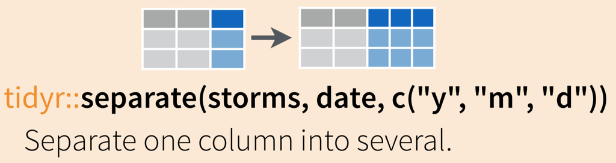

Let’s start again with *inverts_unite*, where we have combined the *site* and *year* into a single column called *site_year*. If we want to **separate** those, we can use:

```r
inverts_sep <- inverts_unite %>%
  separate(site_year, into = c("my_site", "my_year"))
# Here we don't specify how the values should be separated, so we rely on the default, which is a match to any sequence of non alphanumeric values.
# type ?separate to open the usage information for the function and read more about how to separate by a different character.
```

## PART 6: Replace a pattern with `stringr::str_replace()`

Was data entered in a way that’s difficult to code with, or is just plain annoying? Did someone wrongly enter “fish” as “fsh” throughout the spreadsheet, and you want to update it everywhere?

Use `stringr::str_replace()` to automatically replace a string pattern.

**Warning**: The pattern will be replaced everywhere - so if you ask to replace “fsh” with “fish”, then “offshore” would be updated to “offishore”. Be careful to ensure that when you think you’re making one replacement, you’re not also replacing something else unexpectedly.

Starting with inverts, let’s say that any place we find “california” we want to replace it with the abbreviation “CA”:

```r
ca_abbr <- inverts %>%
  mutate(
    common_name =
      str_replace(common_name,
              pattern = "california",
              replacement = "CA")
  )
```

Now, check to confirm that “california” has been replaced with “CA”.

## PART 7: Filtering

In parts 7 and 8 we will use - `filter()` to conditionally subset our data by **rows**, and - `*_join()` functions to merge data frames together

### Objectives

- Use `filter()` to subset data frames, returning **rows** that satisfy variable conditions
- Use `full_join()`, `left_join()`, and `inner_join()` to merge data frames, with different endpoints in mind
- Use `filter()` and `*_join()` as part of a wrangling sequence

### Resources

- [`filter()` documentation from tidyverse.org](https://dplyr.tidyverse.org/reference/filter.html)
- [`join()` documentation from tidyverse.org](https://dplyr.tidyverse.org/reference/join.html)
- [Chapters 5 and 13 in *R for Data Science* by Garrett Grolemund and Hadley Wickham](https://r4ds.had.co.nz/)
- fish.csv
- kelp_fronds.xlsx (read in only the “abur” worksheet by adding argument `sheet = "abur"` to `read_excel()`)

```r
# Read in data:
fish <- read_csv("data/fish.csv")
kelp_abur <- read_excel("data/kelp_fronds.xlsx", sheet = "abur")
```

We should always explore the data we’ve read in. Use functions like `View()`, `names()`, `summary()`, `head()` and `tail()` to check them out. Now, let’s use `filter()` to decide which observations (rows) we’ll keep or exclude in new subsets, similar to using Excel’s VLOOKUP function or filter tool.

## `dplyr::filter()` to conditionally subset by rows

Use `filter()` to let R know which **rows** you want to keep or exclude, based whether or not their contents match conditions that you set for one or more variables.

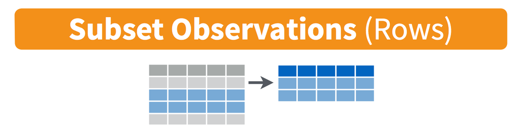

Some examples in words that might inspire you to use `filter()`:

- “I only want to keep rows where the temperature is greater than 90°F.”
- “I want to keep all observations **except** those where the tree type is listed as **unknown**.”
- “I want to make a new subset with only data for mountain lions (the species variable) in California (the state variable).”

When we use `filter()`, we need to let R know a couple of things:

- What data frame we’re filtering from
- What condition(s) we want observations to **match** and/or **not match** in order to keep them in the new subset

Here, we’ll learn some common ways to use `filter()`.

### Filter rows by matching a single character string

Let’s say we want to keep all observations from the **fish** data frame where the common name is “garibaldi” (fun fact: that’s California’s official marine state fish, protected in California coastal waters!).

Here, we need to tell R to only *keep rows* from the **fish** data frame when the common name (**common_name** variable) exactly matches **garibaldi**.

Use `==` to ask R to look for exact matches:

```r
fish_garibaldi <- fish %>%
  filter(common_name == "garibaldi")
```

Check out the **fish_garibaldi** object to ensure that only *garibaldi* observations remain.

#### Activity

**Task**: Create a subset starting from the **fish** data frame, stored as object **fish_mohk**, that only contains observations from Mohawk Reef (site entered as “mohk”).

**Solution**:

```r
fish_mohk <- fish %>%
  filter(site == "mohk")
```

Explore the subset you just created to ensure that only Mohawk Reef observations are returned.

### Filter rows based on numeric conditions

Use expected operators (>, <, >=, <=, ==) to set conditions for a numeric variable when filtering. For this example, we only want to retain observations when the **total_count** column value is >= 50:

```r
fish_over50 <- fish %>%
  filter(total_count >= 50)
```

### Filter to return rows that match *this* OR *that* OR *that*

What if we want to return a subset of the **fish** df that contains *garibaldi*, *blacksmith* OR *black surfperch*?

There are several ways to write an “OR” statement for filtering, which will keep any observations that match Condition A *or* Condition B *or* Condition C. In this example, we will create a subset from **fish** that only contains rows where the **common_name** is *garibaldi* or *blacksmith* or *black surfperch*.

Way 1: You can indicate **OR** using the vertical line operator `|` to indicate “OR”:

```r
fish_3sp <- fish %>%
  filter(common_name == "garibaldi" |
           common_name == "blacksmith" |
           common_name == "black surfperch")
```

#### Activity

**Task:** Create a subset from **fish** called **fish_gar_2016** that keeps all observations if the year is 2016 *OR* the common name is “garibaldi.”

**Solution:**

```r
fish_gar_2016 <- fish %>%
  filter(year == 2016 | common_name == "garibaldi")
```

### Filter to return observations that match **this** AND **that**

In the examples above, we learned to keep observations that matched any of a number of conditions (**or** statements).

Sometimes we’ll only want to keep observations that satisfy multiple conditions (e.g., to keep this observation it must satisfy this condition **AND** that condition). For example, we may want to create a subset that only returns rows from **fish** where the **year** is 2018 *and* the **site** is Arroyo Quemado “aque”

In `filter()`, add a comma (or ampersand ‘&’) between arguments for multiple “and” conditions:

```r
aque_2018 <- fish %>%
  filter(year == 2018, site == "aque")
```

Check it out to see that only observations where the site is “aque” in 2018 are retained:

```r
aque_2018
```

```
## # A tibble: 5 x 4
##    year site  common_name     total_count
##   <dbl> <chr> <chr>                 <dbl>
## 1  2018 aque  black surfperch           2
## 2  2018 aque  blacksmith                1
## 3  2018 aque  garibaldi                 1
## 4  2018 aque  rock wrasse               4
## 5  2018 aque  senorita                 36
```

Like most things in R, there are other ways to do the same thing. For example, you could do the same thing using `&` (instead of a comma) between “and” conditions:

```r
# Use the ampersand (&) to add another condition "and this must be true":
aque_2018 <- fish %>%
  filter(year == 2018 & site == "aque")
```

Or you could just do two filter steps in sequence:

```r
# Written as sequential filter steps:
aque_2018 <- fish %>%
  filter(year == 2018) %>%
  filter(site == "aque")
```

## PART 8: Relational data: merge dataframes with join* functions

There are a number of ways to merge data frames in R. We’ll use `full_join()`, `left_join()`, and `inner_join()` in this session.

From R Documentation (`?join`):

- `full_join()`: “returns all rows and all columns from both x and y. Where there are not matching values, returns NA for the one missing.” Basically, nothing gets thrown out, even if a match doesn’t exist - making `full_join()` the safest option for merging data frames. When in doubt, `full_join()`.
- `left_join()`: “return all rows from x, and all columns from x and y. Rows in x with no match in y will have NA values in the new columns. If there are multiple matches between x and y, all combinations of the matches are returned.”
- `inner_join()`: “returns all rows from x where there are matching values in y, and all columns from x and y. If there are multiple matches between x and y, all combination of the matches are returned.” This will drop observations that don’t have a match between the merged data frames, which makes it a riskier merging option if you’re not sure what you’re trying to do.

Schematic (from RStudio data wrangling cheat sheet):

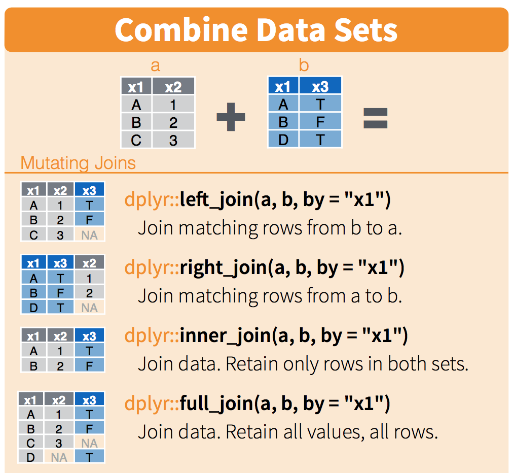

We will use **kelp_abur** as our “left” data frame, and **fish** as our “right” data frame, to explore different join outcomes.

### `full_join()` to merge data frames, keeping everything

When we join data frames in R, we need to tell R a couple of things (and it does the hard joining work for us):

- Which data frames we want to merge together
- Which variables to merge by

Use `full_join()` to safely combine two data frames, keeping everything from both and populating with `NA` as necessary.

Example: use `full_join()` to combine **kelp_abur** and **fish**:

```r
abur_kelp_fish <- kelp_abur %>%
  full_join(fish, by = c("year", "site"))
```

Let’s look at the merged data frame with `View(abur_kelp_fish)`. A few things to notice about how `full_join()` has worked:

1. All columns that existed in **both data frames** still exist
2. All observations are retained, even if they don’t have a match. In this case, notice that for other sites (not ‘abur’) the observation for fish still exists, even though there was no corresponding kelp data to merge with it.
3. The kelp frond data is joined to *all observations* where the joining variables (*year*, *site*) are a match, which is why it is repeated 5 times for each year (once for each fish species).

Because all data (observations & columns) are retained, `full_join()` is the safest option if you’re unclear about how to merge data frames.

### `left_join(x,y)` to merge data frames, keeping everything in the ‘x’ data frame and only matches from the ‘y’ data frame

Now, we want to keep all observations in *kelp_abur*, and merge them with *fish* while only keeping observations from *fish* that match an observation within *abur*. When we use `left_join()`, any information from *fish* that don’t have a match (by year and site) in *kelp_abur* won’t be retained, because those wouldn’t have a match in the left data frame.

```r
kelp_fish_left <- kelp_abur %>%
  left_join(fish, by = c("year","site"))
```

Notice when you look at **kelp_fish_left**, data for other sites that exist in fish do **not** get joined, because `left_join(df_a, df_b)` will only keep observations from `df_b` if they have a match in `df_a`!

### `inner_join()` to merge data frames, only keeping observations with a match in **both**

Use `inner_join()` if you **only** want to retain observations that have matches across **both data** frames. Caution: this is built to exclude any observations that don’t match across data frames by joined variables - double check to make sure this is actually what you want to do!

For example, if we use `inner_join()` to merge fish and kelp_abur, then we are asking R to **only return observations where the joining variables (*year* and *site*) have matches in both data frames.** Let’s see what the outcome is:

```r
kelp_fish_injoin <- kelp_abur %>%
  inner_join(fish, by = c("year", "site"))
# kelp_fish_injoin
```

Here, we see that only observations (rows) where there is a match for *year* and *site* in both data frames are returned.